# Лабораторна робота №6: Аналіз електронної комерції за 2024 рік

Інженерія даних | КрНУ ім. М. Остроградського

© [Andrew Zaykin](https://www.linkedin.com/in/zaykinandrew/), 2026

25.05.2026

## Мета роботи

Провести повний аналіз продуктивності категорій та брендів інтернет-магазину за 2024 рік виключно за допомогою `data.table`.  
- Завантаження великих даних (500 000+ рядків) через `fread()`;  
- Маніпуляції на місці через `:=`;  
- Агрегація з `by`, `.SD`, `.SDcols`;  
- Злиття таблиць через `on`;  
- Побудова пам’ять-ефективного відтворюваного конвеєра.

## Хід роботи

1. **Завантаження даних**
   - Завантажте `sales_2024.csv` через `fread()`.
   - Завантажте `products.csv` через `fread()`.
   - Переконайтеся, що обидва об’єкти є `data.table`.
2. **Підготовка даних**
   - Додайте стовпець `revenue = quantity * price` *на місці* через `:=`.
   - Видаліть стовпці `order_id`, `customer_id` *на місці*.
   - Перетворіть `order_date` на `Date` (якщо потрібно).
3. **Агрегація за категоріями та брендами**
   - Об’єднайте `sales` з `products` через `on = "product_id"`.
   - Для кожної комбінації `category` та `brand` обчисліть:
     - загальний дохід (`total_revenue`),
     - кількість унікальних продуктів (`.N`),
     - середню ціну (`mean(price)`).
   - Використовуйте `by = .(category, brand)`.
   - Відсортуйте результат за спаданням `total_revenue` через `keyby`.
4. **Аналіз за місяцями**
   - Створіть стовпець `month = format(order_date, "%Y-%m")`.
   - Для кожної категорії обчисліть *місячний дохід*.
   - Використовуйте `.SD` та `.SDcols = "revenue"` для агрегації.
5. **Топ-5 продуктів за дохідом**
   - Обчисліть загальний дохід за кожен `product_id`.
   - Виберіть *топ-5 продуктів* за дохідом.
   - Додайте назву продукту через злиття з `products`.
6. **Візуалізація (опціонально)**
   - Перетворіть результат на `data.frame` через `setDF()`.
   - Побудуйте графік дохідності категорій (через `ggplot2`).

Вхідні дані:  
- `sales_2024.csv` — 500 000 записів про замовлення (order_id, customer_id, product_id, quantity, order_date);  
- `products.csv` — довідник продуктів (product_id, product_name, category, brand, price).

### Етап 1: Завантаження даних

```r
sales <- fread("data/sales_2024.csv")
products <- fread("data/products.csv")

cat("=== sales_2024.csv ===\n")
```

```
## === sales_2024.csv ===
```

```r
cat("Клас:", class(sales)[1], "\n")
```

```
## Клас: data.table
```

```r
cat("Розмір:", nrow(sales), "x", ncol(sales), "\n\n")
```

```
## Розмір: 500000 x 5
```

```r
print(head(sales))
```

```
##    order_id customer_id product_id quantity order_date
##       <int>       <int>      <int>    <int>     <IDat>
## 1:        1       46336        183        9 2024-03-20
## 2:        2       29884        200        7 2024-02-03
## 3:        3       33099         88        6 2024-07-05
## 4:        4       46999          2        9 2024-12-03
## 5:        5       46294        139        5 2024-12-11
## 6:        6       19524         48        6 2024-03-09
```

```r
cat("\n=== products.csv ===\n")
```

```
##
## === products.csv ===
```

```r
cat("Клас:", class(products)[1], "\n")
```

```
## Клас: data.table
```

```r
cat("Розмір:", nrow(products), "x", ncol(products), "\n\n")
```

```
## Розмір: 200 x 5
```

```r
print(head(products))
```

```
##    product_id product_name    category   brand  price
##         <int>       <char>      <char>  <char>  <num>
## 1:          1    Product_1 Electronics   Apple 247.22
## 2:          2    Product_2       Books Penguin  95.73
## 3:          3    Product_3 Electronics      LG 380.78
## 4:          4    Product_4 Electronics    Sony 156.05
## 5:          5    Product_5    Clothing    Puma  87.01
## 6:          6    Product_6      Sports  Adidas  21.24
```

```r
stopifnot(is.data.table(sales), is.data.table(products))
cat("\nОбидва об'єкти є data.table ✓\n")
```

```
##
## Обидва об'єкти є data.table ✓
```

### Етап 2: Підготовка даних

```r
sales[, order_date := as.Date(order_date)]

sales[products, price := i.price, on = "product_id"]

sales[, revenue := quantity * price]

sales[, c("order_id", "customer_id") := NULL]

cat("=== Підготовлена таблиця sales ===\n")
```

```
## === Підготовлена таблиця sales ===
```

```r
cat("Стовпці:", paste(names(sales), collapse = ", "), "\n")
```

```
## Стовпці: product_id, quantity, order_date, price, revenue
```

```r
cat("Розмір:", nrow(sales), "x", ncol(sales), "\n\n")
```

```
## Розмір: 500000 x 5
```

```r
print(head(sales, 10))
```

```
##     product_id quantity order_date  price revenue
##          <int>    <int>     <Date>  <num>   <num>
##  1:        183        9 2024-03-20 114.46 1030.14
##  2:        200        7 2024-02-03 421.96 2953.72
##  3:         88        6 2024-07-05 460.16 2760.96
##  4:          2        9 2024-12-03  95.73  861.57
##  5:        139        5 2024-12-11 112.05  560.25
##  6:         48        6 2024-03-09 480.87 2885.22
##  7:         78        7 2024-06-28 105.95  741.65
##  8:        171        2 2024-12-22 113.92  227.84
##  9:         27        3 2024-05-19 405.26 1215.78
## 10:        157        4 2024-06-27 106.27  425.08
```

### Етап 3: Агрегація за категоріями та брендами

```r
merged <- sales[products, on = "product_id", nomatch = 0L]

cat_brand_stats <- merged[, .(
  total_revenue   = sum(revenue, na.rm = TRUE),
  n_products      = uniqueN(product_id),
  avg_price       = mean(price, na.rm = TRUE)
), by = .(category, brand)]

setorder(cat_brand_stats, -total_revenue)

cat("=== Агрегація за category + brand (топ-15) ===\n")
```

```
## === Агрегація за category + brand (топ-15) ===
```

```r
print(head(cat_brand_stats, 15))
```

```
##          category      brand total_revenue n_products avg_price
##            <char>     <char>         <num>      <int>     <num>
##  1:        Beauty Maybelline      29787981          7  308.9637
##  2:         Books   Hachette      28627237          8  262.4777
##  3:      Clothing        H&M      25903063          8  235.2817
##  4: Home & Garden      Bosch      25848285          6  314.0934
##  5:   Electronics     Xiaomi      25791873          6  313.5355
##  6:      Clothing       Nike      24254821          8  218.9133
##  7:      Clothing     Adidas      22931934          7  239.2955
##  8:        Sports       Nike      22678421          5  328.0937
##  9:        Beauty      Nivea      22429164          6  272.0590
## 10:   Electronics       Sony      21667679          7  225.1990
## 11:      Clothing       Puma      20702895          6  252.0299
## 12:        Beauty       Dove      20249930          5  295.4082
## 13:   Electronics    Samsung      20213721          6  245.3426
## 14:   Electronics      Apple      20030916          6  242.7123
## 15:          Food    PepsiCo      19042454          7  199.1876
```

### Етап 4: Аналіз за місяцями

```r
merged[, month := format(order_date, "%Y-%m")]

monthly_revenue <- merged[, lapply(.SD, sum, na.rm = TRUE),
                          by = .(category, month),
                          .SDcols = "revenue"]

setorder(monthly_revenue, category, month)

cat("=== Місячний дохід за категоріями (перші 20 рядків) ===\n")
```

```
## === Місячний дохід за категоріями (перші 20 рядків) ===
```

```r
print(head(monthly_revenue, 20))
```

```
##     category   month revenue
##       <char>  <char>   <num>
##  1:   Beauty 2024-01 8818564
##  2:   Beauty 2024-02 8073656
##  3:   Beauty 2024-03 8622364
##  4:   Beauty 2024-04 8326137
##  5:   Beauty 2024-05 8761370
##  6:   Beauty 2024-06 8157843
##  7:   Beauty 2024-07 8362734
##  8:   Beauty 2024-08 8389749
##  9:   Beauty 2024-09 8285558
## 10:   Beauty 2024-10 8553043
## 11:   Beauty 2024-11 8129867
## 12:   Beauty 2024-12 8660358
## 13:    Books 2024-01 6894481
## 14:    Books 2024-02 6522776
## 15:    Books 2024-03 7071211
## 16:    Books 2024-04 6736480
## 17:    Books 2024-05 7112104
## 18:    Books 2024-06 6816299
## 19:    Books 2024-07 7067008
## 20:    Books 2024-08 7042932
##     category   month revenue
```

### Етап 5: Топ-5 продуктів за дохідом

```r
product_revenue <- merged[, .(total_revenue = sum(revenue, na.rm = TRUE)),
                          by = product_id]

setorder(product_revenue, -total_revenue)
top5 <- product_revenue[1:5]

top5_full <- top5[products, on = "product_id", nomatch = 0L]

cat("=== Топ-5 продуктів за загальним дохідом ===\n")
```

```
## === Топ-5 продуктів за загальним дохідом ===
```

```r
print(top5_full[, .(product_id, product_name, category, brand, total_revenue)])
```

```
##    product_id product_name      category      brand total_revenue
##         <int>       <char>        <char>     <char>         <num>
## 1:         79   Product_79   Electronics       Sony       6960778
## 2:         93   Product_93         Books Scholastic       6780821
## 3:         94   Product_94        Sports       Nike       6869329
## 4:        100  Product_100      Clothing       Nike       6979750
## 5:        158  Product_158 Home & Garden      Dyson       6662681
```

### Етап 6: Візуалізація

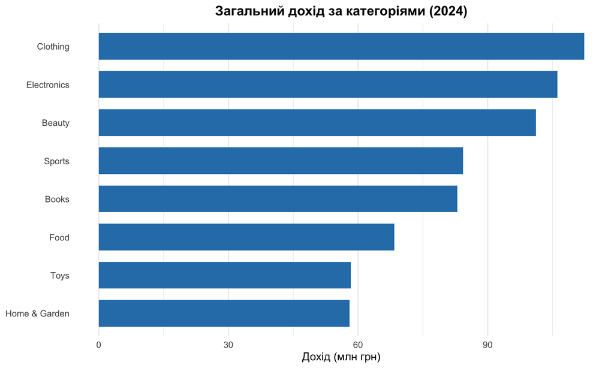

```r
category_totals <- merged[, .(total_revenue = sum(revenue, na.rm = TRUE)),
                          by = category]
setorder(category_totals, -total_revenue)

plot_df <- setDF(copy(category_totals))

ggplot(plot_df, aes(x = reorder(category, total_revenue), y = total_revenue / 1e6)) +

  geom_col(fill = "#2c7fb8", width = 0.7) +
  coord_flip() +
  labs(
    title = "Загальний дохід за категоріями (2024)",
    x = NULL,
    y = "Дохід (млн грн)"
  ) +
  theme_minimal(base_size = 13) +
  theme(
    plot.title = element_text(face = "bold", hjust = 0.5),
    panel.grid.major.y = element_blank()
  )
```

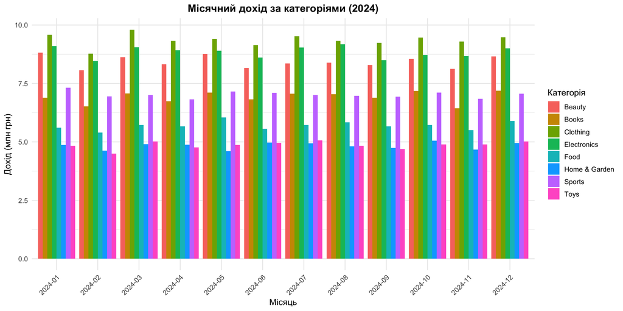

```r
monthly_plot_df <- setDF(copy(monthly_revenue))

ggplot(monthly_plot_df, aes(x = month, y = revenue / 1e6, fill = category)) +
  geom_col(position = "dodge") +
  labs(
    title = "Місячний дохід за категоріями (2024)",
    x = "Місяць",
    y = "Дохід (млн грн)",
    fill = "Категорія"
  ) +
  theme_minimal(base_size = 12) +
  theme(
    axis.text.x = element_text(angle = 45, hjust = 1),
    plot.title = element_text(face = "bold", hjust = 0.5)
  )
```